# 05-Analyzing MACAU results

Laura H Spencer

1/29/2020

### MACAU results - visualize and FDR correct

Ran MACAU in a Jupyter Notebook. See 05-MACAU.ipynb

In this notebook I assess patterns in methylated loci that MACAU identified as associated with the following, while also controlling for relatedness:

1. shell length, with shell whole wet weight as a covariate
2. population

See my Jupyter notebook on these runs: code/05-MACAU.ipynb

### Load libraries

```r
list.of.packages <- c("vegan", "dplyr", "factoextra", "FactoMineR", "tidyverse", "tibble", "reshape2", "gplots", "qvalue", "cluster", "here", "gridExtra", "RColorBrewer") #add new libraries here
new.packages <- list.of.packages[!(list.of.packages %in% installed.packages()[,"Package"])]
if(length(new.packages)) install.packages(new.packages)

# Load all libraries
lapply(list.of.packages, FUN = function(X) {
  do.call("require", list(X))
})
```

### Read in count data

Use dataframes that have the siteID, and original contig, start #, and end # info

```r
head(counts.filtered.meth <- read.table(file = here::here("analyses", "macau", "counts-filtered-meth.txt"), sep = "\t", header=T, stringsAsFactors = F))
```

```
##          siteID numCs1 numCs2 numCs3 numCs4 numCs5 numCs6 numCs7 numCs8 numCs9
## 1 Contig0_39226     11     17     10     14      9     13      9     10     18
## 2 Contig0_39234     10      7     10      5     12     11      7      8      8
## 3 Contig0_64179      9     10      8     20      8     13      5     11      9
## 4 Contig0_71523     16     12     13     16     11      8     11     10     15
## 5 Contig0_71533     21     17     17     17     21     13     17     20     20
## 6 Contig0_71542     21     22     16     14     15     12     28     13     18
##   numCs10 numCs11 numCs12 numCs13 numCs14 numCs15 numCs16 numCs17 numCs18
## 1       9       4      15      10       5       8       8       8       8
## 2       7       1      10       8       5      12       5      12      10
## 3       3       4      14       8      18      17      10      10       7
## 4      19      17      13      24      18      28      18      17      18
## 5      27      22      17      32      23      33      22      23      22
## 6      21      19      12      35      25      32      21      16      21
```

```r
head(counts.filtered.tot <- read.table(file = here::here("analyses", "macau", "counts-filtered-total.txt"), sep = "\t", header=T, stringsAsFactors = F))
```

```
##          siteID coverage1 coverage2 coverage3 coverage4 coverage5 coverage6
## 1 Contig0_39226        21        22        22        23        23        21
## 2 Contig0_39234        24        27        27        26        28        25
## 3 Contig0_64179        10        14         9        21        11        13
## 4 Contig0_71523        16        12        13        18        13         8
## 5 Contig0_71533        21        17        18        17        21        13
## 6 Contig0_71542        23        23        16        14        15        12
##   coverage7 coverage8 coverage9 coverage10 coverage11 coverage12 coverage13
## 1        20        16        31         17          5         23         17
## 2        23        24        36         19          7         29         19
## 3        13        12        15          5          5         19         11
## 4        16        10        16         23         18         14         28
## 5        23        20        21         27         22         21         33
## 6        28        14        18         21         19         12         35
##   coverage14 coverage15 coverage16 coverage17 coverage18
## 1         10         20         13         19         24
## 2         12         25         17         23         32
## 3         24         19         10         10         15
## 4         21         33         21         20         18
## 5         24         36         23         23         23
## 6         26         33         23         17         22
```

### 1. Analyse MACAU results to assess loci where methylation is associated with shell length

#### Read in dataframe with MACAU assocation results

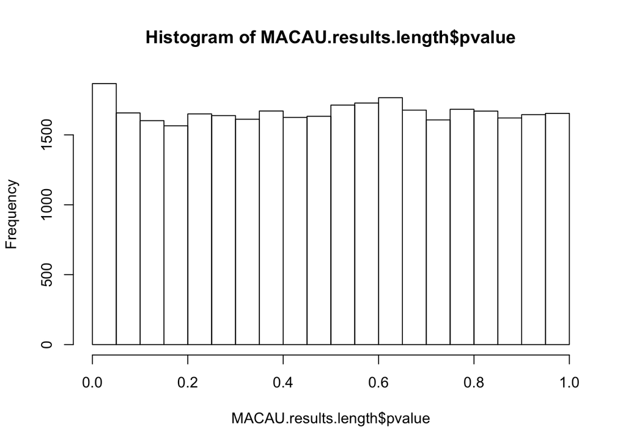

```r
MACAU.results.length <- read.table(file=here::here("analyses","macau","output","20200205-macau.assoc.txt"), sep = "\t", stringsAsFactors = F)
colnames(MACAU.results.length) <- MACAU.results.length[1,]
MACAU.results.length <- MACAU.results.length[-1, ]
MACAU.results.length$pvalue <- as.numeric(MACAU.results.length$pvalue)
hist(MACAU.results.length$pvalue)
```

```r
length(MACAU.results.length$id)
```

```
## [1] 33284
```

```r
length(counts.filtered.tot$siteID)
```

```
## [1] 33284
```

```r
summary(MACAU.results.length$id == counts.filtered.tot$siteID) #confirm that macau results and original destranded dataframe are in same order
```

```
##    Mode    TRUE
## logical   33284
```

```r
MACAU.results.length.c <- cbind(counts.filtered.tot[,1],MACAU.results.length) %>%
   separate(`counts.filtered.tot[, 1]`, into = c("contig", "locus"), sep = "_")
write.table(MACAU.results.length.c, file = here::here("analyses", "macau", "MACAU.results.length.c.tab"), sep = "\t", row.names = FALSE,  quote = FALSE)
```

### Correct for multiple comparisons

From Mac’s 2019 salmon paper, doi:10.3390/genes10050356  
“Multiple hypothesis testing was performed on P-values extracted from the MACAU output for each CG site using the false discovery rate (FDR) approach used in the R package qvalue [45]. We considered a CG site to be differentially methylated (i.e., differentially methylated cytosine (DMC) if it passed a 10% FDR threshold, consistent with [46].”

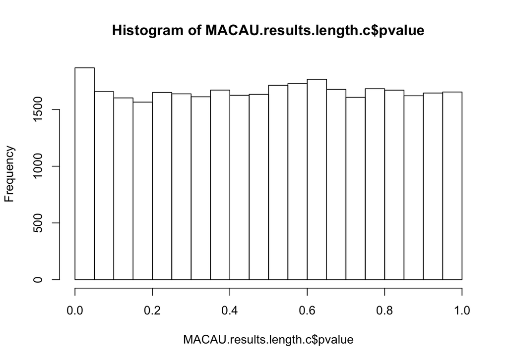

```r
hist(MACAU.results.length.c$pvalue) # p-value distribution looks good (i.e. not u-shaped)
```

```r
MACAU.results.length <- qvalue(p = MACAU.results.length.c$pvalue, fdr.level = 0.1) # create qvalue object, setting FDR=10%

summary(MACAU.results.length)
```

```
##
## Call:
## qvalue(p = MACAU.results.length.c$pvalue, fdr.level = 0.1)
##
## pi0: 0.9899386
##
## Cumulative number of significant calls:
##
##           <1e-04 <0.001 <0.01 <0.025 <0.05 <0.1    <1
## p-value       25    100   492   1049  1866 3523 33284
## q-value        0      0     6      9    16   20 33284
## local FDR      0      0     1      6     8   12  3187
```

```r
100*(1- MACAU.results.length$pi0) #% of all loci in df as truely sign.
```

```
## [1] 1.006138
```

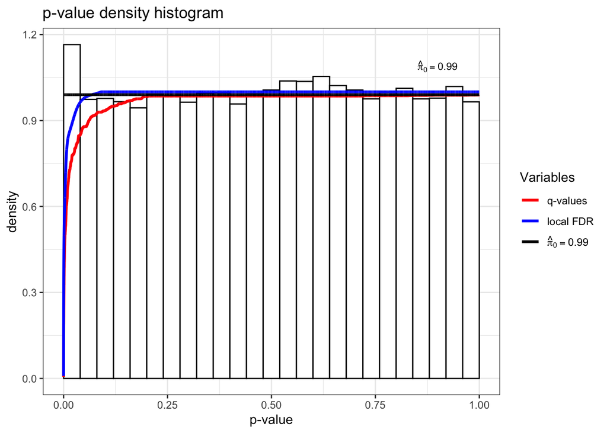

```r
hist(MACAU.results.length)
```

```r
#if one wants to estimate the false discovery rate when calling all p-values ≤ 0.01 significant:
max(MACAU.results.length$qvalues[MACAU.results.length$pvalues <= 0.01])
```

```
## [1] 0.6694966
```

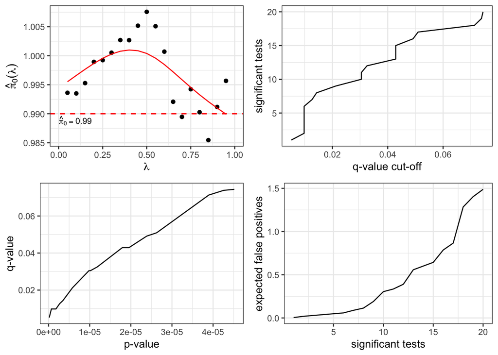

```r
# The main purpose of the upper-left plot is to gauge the reliability of the π0 estimate, where the estimated π0 is plotted versus the tuning parameter λ. The remaining plots show how many tests are significant, as well as how many false positives to expect for each q-value cut-off.
plot(MACAU.results.length)
```

```r
# Given our FDR=10% level, how many are significant?
summary(MACAU.results.length$significant) #20 sign. (# TRUE)
```

```
##    Mode   FALSE    TRUE
## logical   33264      20
```

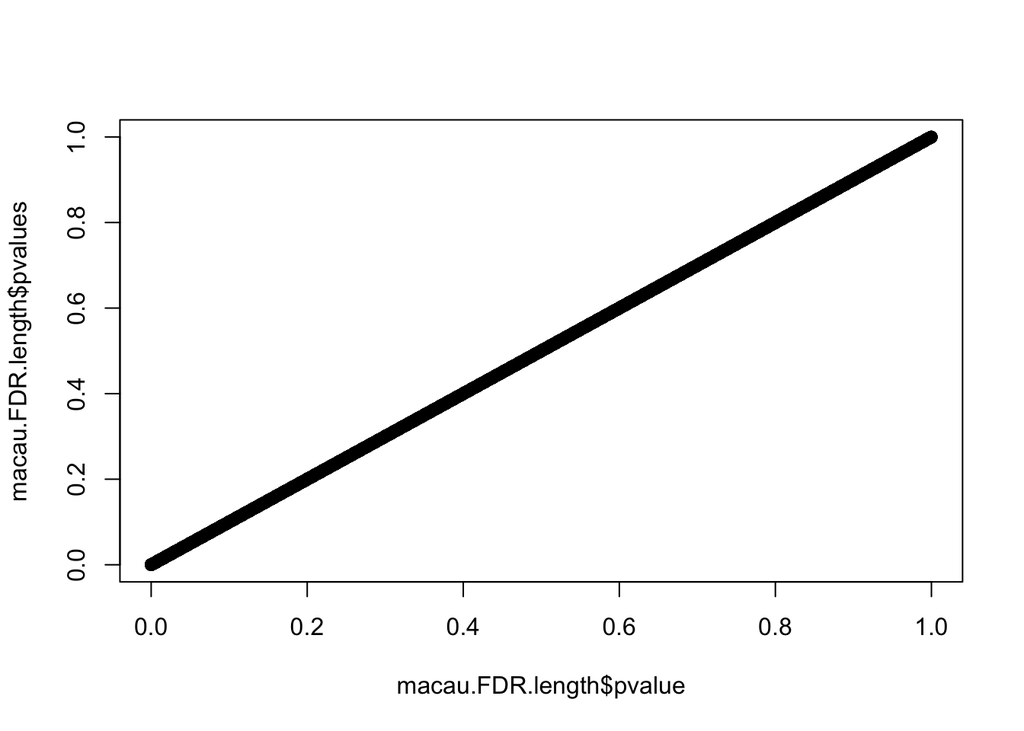

```r
# Add qvalue results to macau df
macau.FDR.length <- cbind(MACAU.results.length.c, do.call(cbind.data.frame, MACAU.results.length[c("qvalues", "pvalues", "significant")]))

#plot macau p-values against pvalues in the qvalue results - should all fall on 1:1 line (double check that pvalues are in same order)
plot(macau.FDR.length$pvalue, macau.FDR.length$pvalues) # looks good!
```

### Extract IDs for loci where MACAU indicates DML, FDR test (at 10%) deemed loci significantt

```r
save(macau.FDR.length, file="../analyses/macau/R-objects/macau.FDR.length")
head(macau.sign.length <- subset(macau.FDR.length, significant=="TRUE"))
```

```
##            contig locus                id  n acpt_rate       beta   se_beta
## 1156 Contig109515  3402 Contig109515_3402 18 2.193e-01 -4.060e-01 7.741e-02
## 1901 Contig120547   984  Contig120547_984 18 3.543e-01 -2.070e-01 5.073e-02
## 3092 Contig138707  4503 Contig138707_4503 18 3.151e-01  4.395e-01 9.365e-02
## 3226 Contig141213  6476 Contig141213_6476 18 2.867e-01  1.034e+00 2.158e-01
## 6984  Contig19176 11627 Contig19176_11627 18 2.846e-01 -4.085e-01 9.930e-02
## 7514  Contig19628   579   Contig19628_579 18 2.665e-01 -3.676e-01 8.330e-02
##         pvalue         h      se_h    sigma2 se_sigma2     alpha0 se_alpha0
## 1156 1.569e-07 7.989e-01 2.186e-01 1.507e+01 1.999e+01  6.733e+00 1.606e+00
## 1901 4.517e-05 3.465e-01 1.817e-01 7.993e-01 7.939e-01  4.128e+00 9.196e-01
## 3092 2.691e-06 6.449e-01 2.903e-01 5.659e+00 1.150e+01 -3.239e+00 1.609e+00
## 3226 1.641e-06 6.892e-01 2.840e-01 1.143e+01 1.344e+01 -1.180e+01 3.283e+00
## 6984 3.897e-05 4.977e-01 2.528e-01 6.705e+00 1.174e+01  5.743e+00 1.743e+00
## 7514 1.017e-05 7.608e-01 2.218e-01 1.241e+01 2.019e+01  7.671e+00 2.011e+00
##          alpha1 se_alpha1     qvalues   pvalues significant
## 1156  3.135e+00 4.608e-01 0.005169716 1.569e-07        TRUE
## 1901  3.960e-02 2.050e-01 0.074415581 4.517e-05        TRUE
## 3092 -1.114e+00 4.003e-01 0.012666582 2.691e-06        TRUE
## 3226 -2.244e+00 6.419e-01 0.009796871 1.641e-06        TRUE
## 6984  2.971e+00 5.400e-01 0.071334839 3.897e-05        TRUE
## 7514  2.339e+00 5.564e-01 0.030462957 1.017e-05        TRUE
```

```r
nrow(macau.sign.length) #number of significant loci = 20
```

```
## [1] 20
```

### Merge MACAU + FDR results with raw count data

Merge macau results with count dataframe, save to file. **These constitute master dataframes**

```r
macau.sign.length.meth.counts <- merge(x=macau.sign.length, y=subset(counts.filtered.meth, siteID %in% macau.sign.length$id), by.x="id", by.y="siteID")
macau.sign.length.tot.counts <- merge(x=macau.sign.length, y=subset(counts.filtered.tot, siteID %in% macau.sign.length$id), by.x="id", by.y="siteID")
write.table(macau.sign.length.meth.counts, file = here::here("analyses", "macau", "combined-macau-FDR-meth-counts.length.txt"), sep = "\t", row.names = FALSE,  quote = FALSE)
write.table(macau.sign.length.tot.counts, file = here::here("analyses", "macau", "combined-macau-FDR-tot-counts.length.txt"), sep = "\t", row.names = FALSE,  quote = FALSE)
```

### Create df where coverage counts <5 replaced with NA, & create % methylated dataframe with sign. MACAU loci

```r
macau.sign.length.tot.counts.na <- macau.sign.length.tot.counts %>%
  mutate_at(vars(contains('coverage')), funs(ifelse(. < 5, NA, .)))
macau.sign.length.perc.meth <- macau.sign.length.meth.counts
macau.sign.length.perc.meth[,20:37] <- 100*(macau.sign.length.meth.counts[,20:37]/macau.sign.length.tot.counts.na[,20:37])
```

### Heatmaps

#### Prep order vectors

```r
size <- read.csv(file = here::here("data","mbd_size.csv"), header=T, sep = "\t")
key <- read.csv(file=here::here("data","sample-key.csv"))
size.macau <- cbind(x=c(rep(1,times=18)), y=merge(y=size, x=key, by.y="Sample", by.x="SAMPLE")) %>%
  mutate(population=as.factor(c(rep("HC", times=9), rep("SS",  times=9)))) %>%
  mutate(sample=paste("numCs", y.MBD.FILENAME, sep="")) %>%
  arrange(y.Length)
mycols <- c("firebrick3", "dodgerblue3")

tree.order <- paste("numCs",c(15,17,12,10,11,13,18,14,16,8,1,6,9,2,4,5,3,7), sep="")
size.order <- paste("numCs",c(size.macau[order(size.macau$y.Length),"y.MBD.FILENAME"]), sep="")

pop.colors.tree <- c(rep("dodgerblue3", times=9), rep("firebrick3", times=9))
pop.colors.length <- c("dodgerblue3", rep("firebrick3", times=7), rep("dodgerblue3", times=3), "firebrick3","dodgerblue3","firebrick3",rep("dodgerblue3", times=4))

macau.sign.length.perc.meth <- macau.sign.length.perc.meth %>%
  mutate(mean.HC = rowMeans(macau.sign.length.perc.meth[,20:28])) %>%
  mutate(mean.SS = rowMeans(macau.sign.length.perc.meth[,29:37])) %>%
  mutate(HC.SS.ratio = mean.HC/mean.SS) %>%
  arrange(HC.SS.ratio)
rownames(macau.sign.length.perc.meth) <- macau.sign.length.perc.meth[,1]

save(macau.sign.length.perc.meth, file="../analyses/macau/R-objects/macau.sign.length.perc.meth")
save(size.macau, file="../analyses/macau/R-objects/size.macau")
```

#### Heatmap of loci associated with shell length, ordered by the heatmap cluster analysis

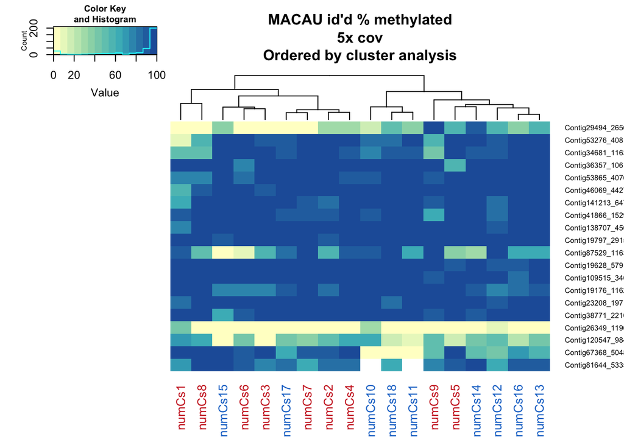

```r
par(cex.main=.8)
heatmap.2(as.matrix(macau.sign.length.perc.meth[, grep(c("numCs"), colnames(macau.sign.length.perc.meth))]),
          main = "MACAU id'd % methylated\n5x cov\nOrdered by cluster analysis",
          xlab = NA, ylab = NA,
          hclustfun = function(x) hclust(x, method="ward.D"), distfunc <- function(x) daisy(x,metric="correlation"), trace="none", dendrogram = "column", na.color = "white",
          col = colorRampPalette(brewer.pal(4,"YlGnBu")), colCol = c(rep("firebrick3", times=9), rep("dodgerblue3", times=9)), cexRow = 0.6)
```

#### Heatmap of loci associated with shell length, ordered by cluster analysis from MethylKit

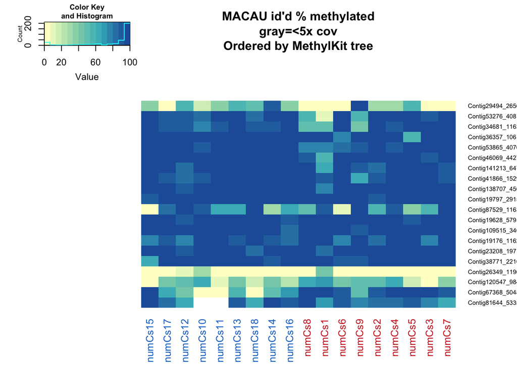

```r
par(cex.main=.8)
heatmap.2(as.matrix(macau.sign.length.perc.meth[, grep(c("numCs"), colnames(macau.sign.length.perc.meth))][tree.order]),
          main = "MACAU id'd % methylated\ngray=<5x cov\nOrdered by MethylKit tree",
         xlab = NA,
         na.color = "white",trace="none", dendrogram = "none", Rowv=FALSE, Colv = FALSE,
          col = colorRampPalette(brewer.pal(4,"YlGnBu")), colCol = pop.colors.tree, cexRow = 0.6)
```

#### Heatmap of loci associated with shell length, ordered by shell length

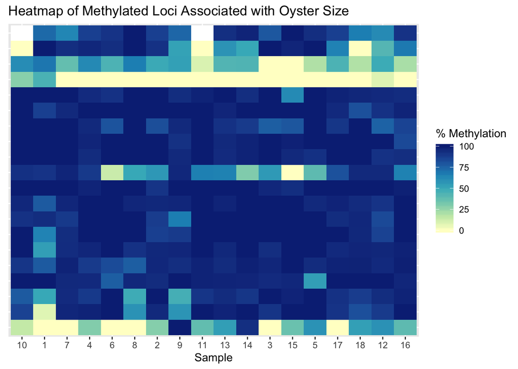

```r
# par(cex.main=.8)
# heatmap.2(as.matrix(macau.sign.length.perc.meth[, grep(c("numCs"), colnames(macau.sign.length.perc.meth))][size.order]),
#           main = "MACAU id'd % methylation\nFDR=10%\nOrdered by Length",
#           xlab = NA, ylab = NA,
#           trace="none", dendrogram = "none", Rowv=FALSE, Colv = FALSE,
#           col = colorRampPalette(brewer.pal(4,"YlGnBu")), colCol = pop.colors.length, cexRow = 0.6)

#ggplotly(
as.matrix(macau.sign.length.perc.meth[, grep(c("numCs"), colnames(macau.sign.length.perc.meth))][size.order]) %>%
  melt(value.name = "perc.meth", varnames = c("locus", "sample")) %>%
ggplot(aes(sample, locus, fill= perc.meth)) + xlab("Sample") + geom_tile(na.rm = T) +
  scale_x_discrete(breaks=colnames(as.matrix(macau.sign.length.perc.meth[, grep(c("numCs"), colnames(macau.sign.length.perc.meth))][size.order])), labels=c("10","1","7","4","6","8","2","9","11","13","14","3","15","5","17","18","12","16")) +
  #scale_fill_viridis(discrete=FALSE)
  theme(axis.title.y=element_blank(),
        axis.text.y=element_blank(),
        axis.ticks.y=element_blank()) +
  ggtitle("Heatmap of Methylated Loci Associated with Oyster Size") +
  ylab("Loci") +
  scale_fill_distiller(name = "% Methylation", palette = "YlGnBu", direction = 1, na.value="white")
```

```r
  #scale_fill_gradient(low="gray5", high="white") #)
  #scale_fill_gradient(low="gray5", high="white")
```

#### Barplot of shell length, ordered by length

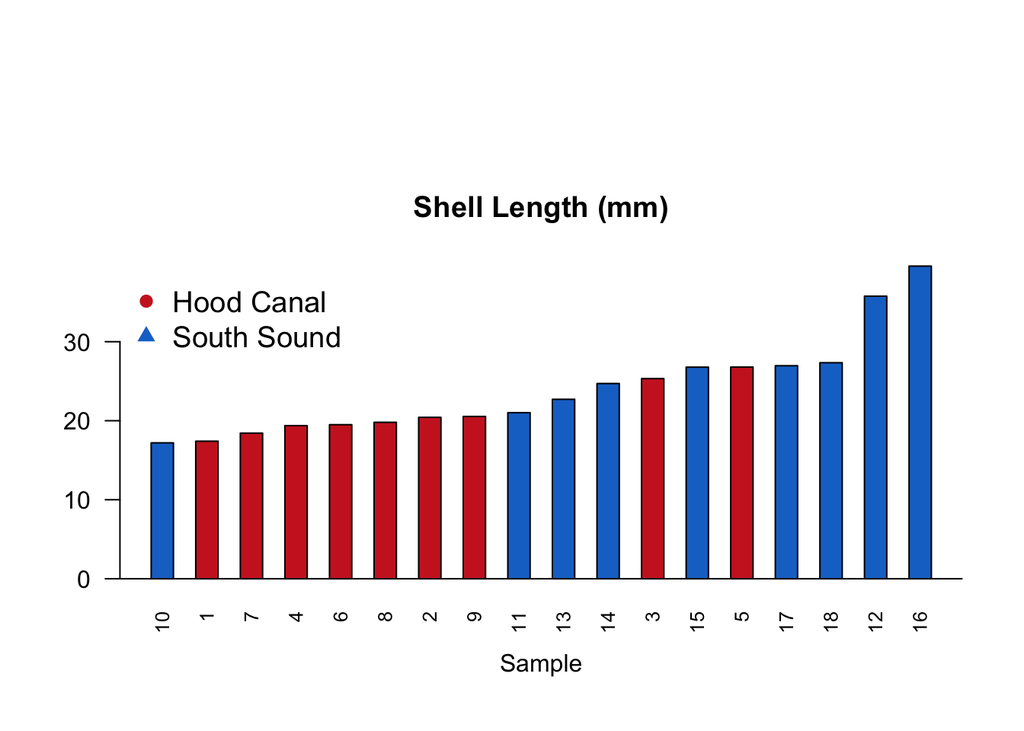

```r
par(oma=c(0,0,5,0))
barplot(size.macau[order(size.macau$y.Length),]$y.Length,  names.arg = size.macau[order(size.macau$y.Length),]$y.MBD.FILENAME, col = mycols[size.macau[order(size.macau$y.Length),]$pop], cex.names =  0.8, main = "Shell Length (mm)", las=2, space=1) #could add this to cut yaxis off at 10mm: (ylim=c(10,40), xpd = FALSE)
abline(h = 0, col = "black", lwd = 1)
legend("topleft",
       pch = c(16, 17),
       legend = c("Hood Canal", "South Sound"),
       col = c(c("firebrick3", "dodgerblue3")),
       cex = 1.2, bty = "n") #Add a legend with information about ambient and elevated samples
mtext(side = 1, text = "Sample", line = 2.25, cex = 1) #Add x-axis label
```

### Create BED-type files

```r
macau.sign.length.perc.meth %>%
  mutate(end = locus) %>%
  rename(start = locus) %>%
  dplyr::select(c("contig", "start", "end")) %>%
write_delim(here::here("analyses","macau", "macau.sign.length.perc.meth.bed"),  delim = '\t', col_names = FALSE)

# All loci fed into/from macau
MACAU.results.length.c %>%
  mutate(end = locus) %>%
  rename(start = locus) %>%
  dplyr::select(c("contig", "start", "end")) %>%
write_delim(here::here("analyses","macau", "macau-all-loci.bed"),  delim = '\t', col_names = FALSE)

# All loci fed into/from macau with q-values
macau.FDR.length %>%
write_delim(here::here("analyses","macau", "macau-all-loci_qvalues.tab"),  delim = '\t', col_names = FALSE)
```

### Do any MACAU length loci overlap with DMLs? Answer: yes, 1 locus.

```r
load("../analyses/DMLs/R-objects/dml25")
macau.sign.length %>%
  mutate_at(vars(locus), funs(as.integer)) %>%
  dplyr::filter(contig %in% dml25$chr, locus %in% c(dml25$start+1))
```

```
##        contig locus               id  n acpt_rate      beta   se_beta    pvalue
## 1 Contig67368  5048 Contig67368_5048 18 1.623e-01 4.584e-01 1.070e-01 1.842e-05
##           h      se_h    sigma2 se_sigma2     alpha0 se_alpha0     alpha1
## 1 8.804e-01 1.924e-01 6.033e+01 3.966e+01 -4.465e+00 2.405e+00 -2.667e+00
##   se_alpha1    qvalues   pvalues significant
## 1 4.827e-01 0.04289975 1.842e-05        TRUE
```

### Do any MACAU loci overlap with DMGs? Answer: No.

```r
load("../analyses/DMGs/R-objects/DMLs.in.DMGs_2kbslop")
macau.sign.length %>%
  mutate_at(vars(locus), funs(as.integer)) %>%
  dplyr::filter(contig %in% DMLs.in.DMGs_2kbslop$chr, locus %in% c(DMLs.in.DMGs_2kbslop$start+1))
```

```
##  [1] contig      locus       id          n           acpt_rate   beta
##  [7] se_beta     pvalue      h           se_h        sigma2      se_sigma2
## [13] alpha0      se_alpha0   alpha1      se_alpha1   qvalues     pvalues
## [19] significant
## <0 rows> (or 0-length row.names)
```